# HW4_Statistical Machine Learning

Moran Guo

2024-10-09

## Question 1 (8.4-10)

### (a)

```r
# Load required packages
library(ISLR)

data <- Hitters
data <- data[!is.na(data$Salary), ]
data$Salary <- log(data$Salary)

head(data)
```

```
##                   AtBat Hits HmRun Runs RBI Walks Years CAtBat CHits CHmRun
## -Alan Ashby         315   81     7   24  38    39    14   3449   835     69
## -Alvin Davis        479  130    18   66  72    76     3   1624   457     63
## -Andre Dawson       496  141    20   65  78    37    11   5628  1575    225
## -Andres Galarraga   321   87    10   39  42    30     2    396   101     12
## -Alfredo Griffin    594  169     4   74  51    35    11   4408  1133     19
## -Al Newman          185   37     1   23   8    21     2    214    42      1
##                   CRuns CRBI CWalks League Division PutOuts Assists Errors
## -Alan Ashby         321  414    375      N        W     632      43     10
## -Alvin Davis        224  266    263      A        W     880      82     14
## -Andre Dawson       828  838    354      N        E     200      11      3
## -Andres Galarraga    48   46     33      N        E     805      40      4
## -Alfredo Griffin    501  336    194      A        W     282     421     25
## -Al Newman           30    9     24      N        E      76     127      7
##                     Salary NewLeague
## -Alan Ashby       6.163315         N
## -Alvin Davis      6.173786         A
## -Andre Dawson     6.214608         N
## -Andres Galarraga 4.516339         N
## -Alfredo Griffin  6.620073         A
## -Al Newman        4.248495         A
```

### (b)

```r
set.seed(644)

training_set <- data[1:200, ]
test_set <- data[201:nrow(data), ]

dim(training_set)
```

```
## [1] 200  20
```

```r
dim(test_set)
```

```
## [1] 63 20
```

### (c)

```r
library(gbm)
```

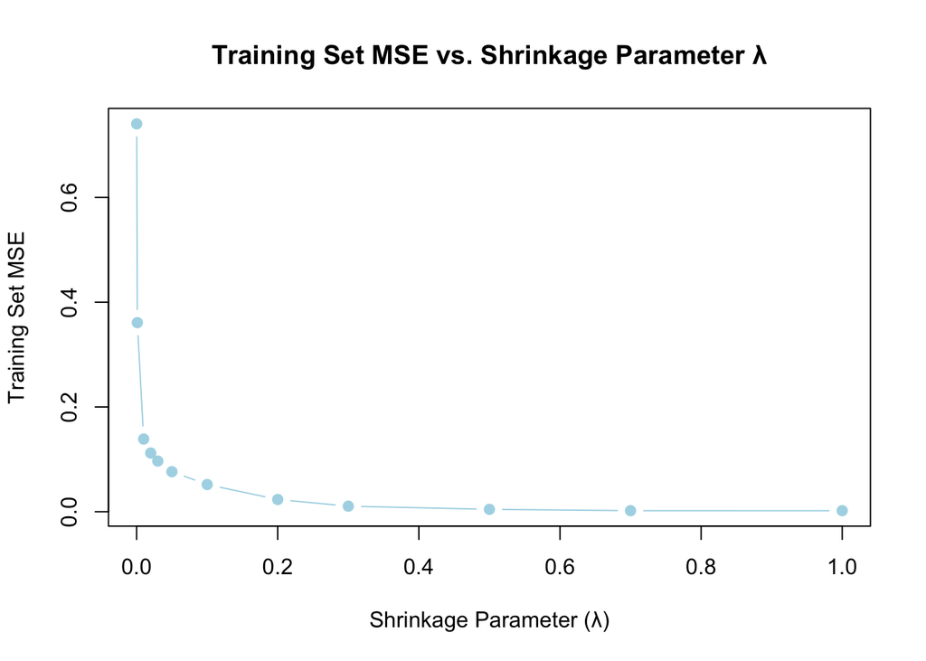

```r
shrinkage_val <- c(0.0001, 0.001, 0.01, 0.02, 0.03, 0.05, 0.1, 0.2, 0.3, 0.5, 0.7, 1)

training_mse <- numeric(length(shrinkage_val))

for (i in seq_along(shrinkage_val)) {
  boost_model <- gbm(
    formula = Salary ~ .,
    data = training_set,
    distribution = "gaussian",
    n.trees = 1000,
    shrinkage = shrinkage_val[i]
  )
  train_pred <- predict(boost_model, training_set, n.trees = 1000)
  training_mse[i] <- mean((train_pred - training_set$Salary)^2)
}

plot(shrinkage_val, training_mse, type = 'b', pch = 19, col = "lightblue",
     xlab = "Shrinkage Parameter (λ)", ylab = "Training Set MSE",
     main = "Training Set MSE vs. Shrinkage Parameter λ")
```

### (d)

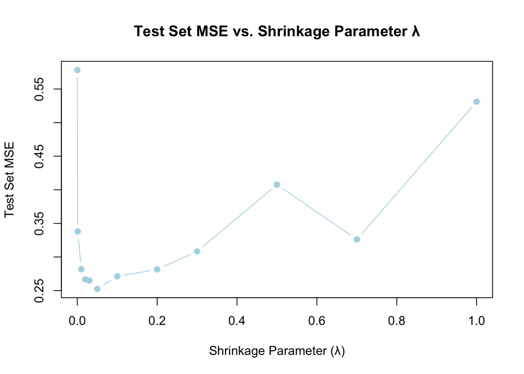

```r
test_mse <- numeric(length(shrinkage_val))

for (i in seq_along(shrinkage_val)) {

  boost_model <- gbm(
    formula = Salary ~ .,
    data = training_set,
    distribution = "gaussian",
    n.trees = 1000,
    shrinkage = shrinkage_val[i]
  )

  test_pred <- predict(boost_model, test_set, n.trees = 1000)
  test_mse[i] <- mean((test_pred - test_set$Salary)^2)
}

results <- data.frame(Shrinkage = shrinkage_val, Test_MSE = test_mse)

plot(shrinkage_val, test_mse, type = "b", pch = 19, col = "lightblue",
     xlab = "Shrinkage Parameter (λ)", ylab = "Test Set MSE",
     main = "Test Set MSE vs. Shrinkage Parameter λ")
```

```r
results
```

```
##    Shrinkage  Test_MSE
## 1      1e-04 0.5781709
## 2      1e-03 0.3381118
## 3      1e-02 0.2817857
## 4      2e-02 0.2668207
## 5      3e-02 0.2648282
## 6      5e-02 0.2524691
## 7      1e-01 0.2712603
## 8      2e-01 0.2815257
## 9      3e-01 0.3081873
## 10     5e-01 0.4077542
## 11     7e-01 0.3262251
## 12     1e+00 0.5311776
```

### (e)

I will fit a **simple linear regression model** and a **Ridge regression model**, and then calculate & compare test MSE.

```r
# Load required packagge
library(glmnet)
# Simple linear regression model
linear_model <- lm(Salary ~ ., data = training_set)

linear_pred <- predict(linear_model, newdata = test_set)

linear_test_mse <- mean((linear_pred - test_set$Salary)^2)

print(paste("Linear Regression Test MSE:", linear_test_mse))
```

```
## [1] "Linear Regression Test MSE: 0.491795937545494"
```

```r
# Ridge regression model

x_train <- model.matrix(Salary ~ ., data = training_set)[, -1]
y_train <- training_set$Salary
x_test <- model.matrix(Salary ~ ., data = test_set)[, -1]

ridge_model <- cv.glmnet(x_train, y_train, alpha = 0, standardize = TRUE)

ridge_pred <- predict(ridge_model, s = ridge_model$lambda.min, newx = x_test)

ridge_test_mse <- mean((ridge_pred - test_set$Salary)^2)
print(paste("Ridge Regression Test MSE:", ridge_test_mse))
```

```
## [1] "Ridge Regression Test MSE: 0.450011294664391"
```

### (f)

```r
importance <- summary(boost_model)
```

[figure not shown]

```r
print(importance)
```

```
##                 var    rel.inf
## CAtBat       CAtBat 19.2356598
## PutOuts     PutOuts 13.4808468
## Walks         Walks  9.4617206
## Assists     Assists  6.8186736
## RBI             RBI  6.1789857
## Years         Years  5.7246771
## CRuns         CRuns  5.0302289
## Hits           Hits  4.7113076
## Errors       Errors  4.6474850
## HmRun         HmRun  4.6358869
## CRBI           CRBI  4.4733008
## CHmRun       CHmRun  4.0435827
## CWalks       CWalks  3.0442785
## AtBat         AtBat  2.8319917
## Runs           Runs  2.3148928
## League       League  1.2934815
## CHits         CHits  0.9511353
## NewLeague NewLeague  0.5770201
## Division   Division  0.5448446
```

```r
#summary(boost_model, cBars = 6, las = 1, main = "Variable Importance")
```

From both the importance table & the figure, we can conclude that variables `CAtBat`, `PutOuts`, `Walks` are the three most important ones.

### (g)

```r
library(randomForest)
set.seed(999)

bagging_model <- randomForest(Salary ~ ., data = training_set, mtry = ncol(training_set) - 1, ntree = 1000, importance = TRUE)

bagging_pred <- predict(bagging_model, newdata = test_set)
bagging_test_mse <- mean((bagging_pred - test_set$Salary)^2)
print(paste("Bagging Test MSE:", bagging_test_mse))
```

```
## [1] "Bagging Test MSE: 0.231606690060947"
```

So the MSE of Bagging is approximately $0.2316$, this is lower than the value of Boosting, Linear & Ridge Regression.

## Question 2 (9.7-7)

### (a)

```r
# Load required packages
library(ISLR)

data_auto <- Auto
mpg_median <- median(Auto$mpg)
data_auto$mpg_high <- ifelse(Auto$mpg > mpg_median, 1, 0)
head(data_auto)
```

```
##   mpg cylinders displacement horsepower weight acceleration year origin
## 1  18         8          307        130   3504         12.0   70      1
## 2  15         8          350        165   3693         11.5   70      1
## 3  18         8          318        150   3436         11.0   70      1
## 4  16         8          304        150   3433         12.0   70      1
## 5  17         8          302        140   3449         10.5   70      1
## 6  15         8          429        198   4341         10.0   70      1
##                        name mpg_high
## 1 chevrolet chevelle malibu        0
## 2         buick skylark 320        0
## 3        plymouth satellite        0
## 4             amc rebel sst        0
## 5               ford torino        0
## 6          ford galaxie 500        0
```

### (b)

Based on previous result of the `Auto` dataset, I intuitively choose variables `displacement` and `weight` to train and build an SVM classifier to separate high and low mpg cars.

```r
# Load required packages
library(e1071)

set.seed(1234)

data_auto$mpg_high <- as.factor(data_auto$mpg_high)


svm_linear_tune <- tune(svm, mpg_high ~ displacement + weight, data = data_auto, kernel = "linear", ranges = list(cost = c(0.001, 0.01, 0.1, 1, 10, 100)))

summary(svm_linear_tune)
```

```
##
## Parameter tuning of 'svm':
##
## - sampling method: 10-fold cross validation
##
## - best parameters:
##  cost
##   0.1
##
## - best performance: 0.09692308
##
## - Detailed performance results:
##    cost      error dispersion
## 1 1e-03 0.20160256 0.11874932
## 2 1e-02 0.10461538 0.04086261
## 3 1e-01 0.09692308 0.04637274
## 4 1e+00 0.09948718 0.05183269
## 5 1e+01 0.09948718 0.05183269
## 6 1e+02 0.09948718 0.05183269
```

Based on the error of the cross-validation (and the summaries), we conclude that `cost = 0.1` leads to the lowest error rate. Cost value lower than $0.1$ leads to higher error rates, suggesting evidence of underfitting; while higher cost values indicating overfitting since the model is too complex to account for the testing data.

### (c)

```r
# Load required packages
library(e1071)

set.seed(1001)

cost <- c(0.001, 0.01, 0.1, 1, 10, 100)
gamma <- c(0.0001, 0.001, 0.1, 0.5, 1, 2, 3, 4)

svm_tune_rad <- tune(svm, mpg_high ~ displacement + weight, data = data_auto, kernel = "radial", ranges = list(cost = cost, gamma = gamma))

summary(svm_tune_rad)
```

```
##
## Parameter tuning of 'svm':
##
## - sampling method: 10-fold cross validation
##
## - best parameters:
##  cost gamma
##   100   0.1
##
## - best performance: 0.09448718
##
## - Detailed performance results:
##     cost gamma      error dispersion
## 1  1e-03 1e-04 0.54333333 0.03720183
## 2  1e-02 1e-04 0.54333333 0.03720183
```

[output cut: 46 more lines]

```r
best <- svm_tune_rad$best.model
summary(best)
```

```
##
## Call:
## best.tune(METHOD = svm, train.x = mpg_high ~ displacement + weight,
##     data = data_auto, ranges = list(cost = cost, gamma = gamma),
##     kernel = "radial")
##
##
## Parameters:
##    SVM-Type:  C-classification
##  SVM-Kernel:  radial
##        cost:  100
##
## Number of Support Vectors:  101
##
##  ( 51 50 )
##
##
## Number of Classes:  2
##
## Levels:
##  0 1
```

```r
# Load required packages
library(e1071)

degrees <- c(2, 3, 4)

svm_tune_poly <- tune(svm, mpg_high ~ displacement + weight, data = data_auto, kernel = "polynomial", ranges = list(cost = cost, degree = degrees))

summary(svm_tune_poly)
```

```
##
## Parameter tuning of 'svm':
##
## - sampling method: 10-fold cross validation
##
## - best parameters:
##  cost degree
##   0.1      3
##
## - best performance: 0.1580769
##
## - Detailed performance results:
##     cost degree     error dispersion
## 1  1e-03      2 0.5764744 0.04744364
## 2  1e-02      2 0.4315385 0.09951890
## 3  1e-01      2 0.3674359 0.06957667
## 4  1e+00      2 0.3519872 0.07361255
## 5  1e+01      2 0.3241667 0.07907141
## 6  1e+02      2 0.3217308 0.08395802
## 7  1e-03      3 0.3572436 0.08092513
## 8  1e-02      3 0.2653205 0.06826276
## 9  1e-01      3 0.1580769 0.06134168
## 10 1e+00      3 0.1709615 0.05863432
## 11 1e+01      3 0.1785897 0.05743707
## 12 1e+02      3 0.1912179 0.05371716
## 13 1e-03      4 0.4261538 0.05957654
## 14 1e-02      4 0.3674359 0.08442783
## 15 1e-01      4 0.3699359 0.07155692
## 16 1e+00      4 0.3521154 0.07430004
## 17 1e+01      4 0.3112821 0.09121114
## 18 1e+02      4 0.3112821 0.09200856
```

From the results, we can see that for the SVM radial kernel fit, the optimal parameters are `cost = 100` and $\gamma = 0.1$; for the SVM polynomial kernel fit, the optimal parameters are `cost = 0.1` and `degree = 3`. Moreover, we could see that the optimal error rates for radial SVM ($0.0945$) is the smallest (thus the best) compared to linear ($0.0969$) and polynomial SVM ($0.1581$), although the error rate difference between the radial and linear SVM could be negligible. I thus conclude that radial SVM models the relationship between `mpg_high` and the rest variables better. This is likely to happen if the relationship of car’s mpg and its displacement & weight is not so much linear; however, we need to keep in mind that the linear SVM performed almost equally well compared to the radial kernel. The poor performance of polynomial kernel, on the other hand, suggests that there might not exist a high-order relationship between car’s mpg and its displacement & weight.

### (d)

Based on previous output:

The best model for **linear kernel** is: cost = $0.1$;

The best model for **radial kernel** is: cost = $100$, $\gamma = 0.1$;

The best model for **polynomial kernel** is: cost = $0.1$, degree = $3$.

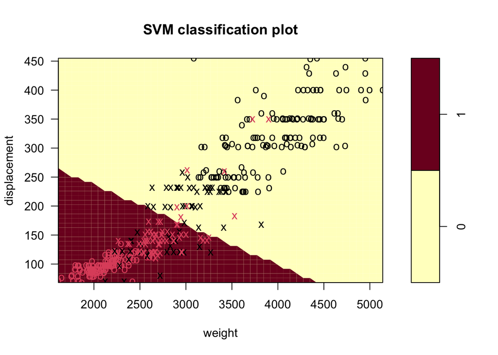

```r
library(e1071)

# Best linear model
best_linear_svm <- svm(mpg_high ~ displacement + weight, data = data_auto, kernel = "linear", cost = 0.1)

plot(best_linear_svm, data_auto, displacement ~ weight)
```

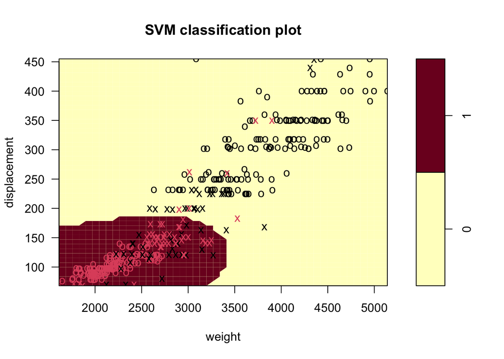

```r
# Best radial model
best_radial_svm <- svm(mpg_high ~ displacement + weight, data = data_auto, kernel = "radial", cost = 100, gamma = 0.1)

plot(best_radial_svm, data_auto, displacement ~ weight)
```

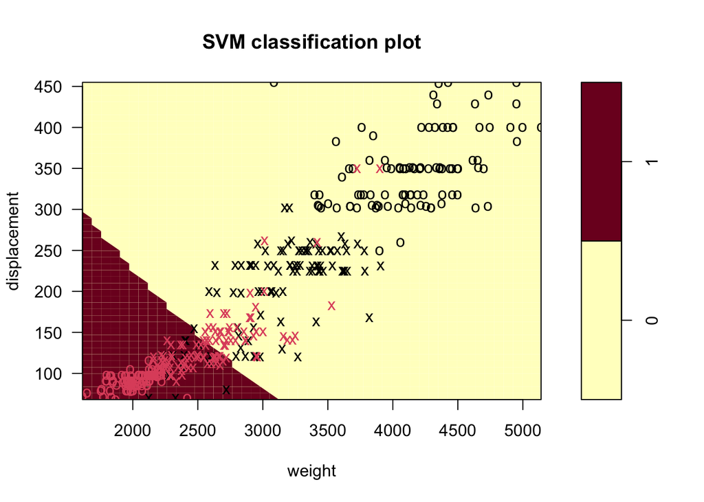

```r
# Best polynomial model
best_polynomial_svm <- svm(mpg_high ~ displacement + weight, data = data_auto, kernel = "polynomial", cost = 0.1, degree = 3)

plot(best_polynomial_svm, data_auto, displacement ~ weight)
```

**Discussion**:

All three plots suggest negative relationships between car’s displacement & mpg and also car’s weight & mpg. This aligns with our previous discoveries of the dataset using correlation matrix. Looking at the decision boundaries, it seems that the radial SVM is the most accurate one, since it has a relatively convergent & accurate boundary compared to the rest two. Polynomial kernel drawn the boundary too conservative, so that it mis-classified a lot of high-mpg data point into the lower half. Generally, the SVM classification plots using the best parameters support our previous conclusion: radial kernel performs the best, but linear kernel is also good in separating the two categories.

## Question 3 (9.7-8)

### (a)

```r
# Load required packages
library(ISLR)

library(dplyr)
data("OJ")

set.seed(233)

train_index <- sample(seq_len(nrow(OJ)), size = 800)

train_set <- OJ[train_index, ]
test_set <- OJ[-train_index, ]

print(nrow(train_set))
```

```
## [1] 800
```

```r
print(nrow(test_set))
```

```
## [1] 270
```

### (b)

```r
library(e1071)

svm_fit <- svm(Purchase ~ ., data = train_set, kernel = "linear", cost = 0.01, scale = TRUE)

summary(svm_fit)
```

```
##
## Call:
## svm(formula = Purchase ~ ., data = train_set, kernel = "linear",
##     cost = 0.01, scale = TRUE)
##
##
## Parameters:
##    SVM-Type:  C-classification
##  SVM-Kernel:  linear
##        cost:  0.01
##
## Number of Support Vectors:  452
##
##  ( 227 225 )
##
##
## Number of Classes:  2
##
## Levels:
##  CH MM
```

### (c)

```r
train_preds <- predict(svm_fit, train_set)
train_error_rate <- mean(train_preds != train_set$Purchase)
cat("Training error rate:", train_error_rate, "\n")
```

```
## Training error rate: 0.1825
```

```r
test_preds <- predict(svm_fit, test_set)
test_error_rate <- mean(test_preds != test_set$Purchase)
cat("Test error rate:", test_error_rate, "\n")
```

```
## Test error rate: 0.1222222
```

### (d)

```r
set.seed(1342)
tune_svm <- tune(
  svm,
  Purchase ~ .,
  data = train_set,
  kernel = "linear",
  ranges = list(cost = c(0.001, 0.01, 0.05, 0.1, 1, 2, 5, 10))
)

summary(tune_svm)
```

```
##
## Parameter tuning of 'svm':
##
## - sampling method: 10-fold cross validation
##
## - best parameters:
##  cost
##    10
##
## - best performance: 0.1775
##
## - Detailed performance results:
##    cost   error dispersion
## 1 1e-03 0.32500 0.08858455
## 2 1e-02 0.20125 0.04910660
## 3 5e-02 0.20000 0.04289846
## 4 1e-01 0.19375 0.04419417
## 5 1e+00 0.19000 0.04362084
## 6 2e+00 0.19000 0.04518481
## 7 5e+00 0.18250 0.04830459
## 8 1e+01 0.17750 0.05130248
```

Based on the tune results, we can see that `cost` equals to $10$ achieved the smallest error rates.

### (e)

We use `cost = 10` to compute the training and test error rates.

```r
svm_best <- tune_svm$best.model

train_pred_best <- predict(svm_best, train_set)
train_error_best <- mean(train_pred_best != train_set$Purchase)
cat("Training error rate for the best linear SVM model:", train_error_rate, "\n")
```

```
## Training error rate for the best linear SVM model: 0.1825
```

```r
test_pred_best <- predict(svm_best, test_set)
test_error_best <- mean(test_pred_best != test_set$Purchase)
cat("Testing set error rate for the best linear SVM model:", test_error_best, "\n")
```

```
## Testing set error rate for the best linear SVM model: 0.1259259
```